# Test a Perceptual Phenomenon

### Analyzing the Stroop Effect

Perform the analysis in the space below. Remember to follow [the instructions](https://docs.google.com/document/d/1-OkpZLjG_kX9J6LIQ5IltsqMzVWjh36QpnP2RYpVdPU/pub?embedded=True) and review the [project rubric](https://review.udacity.com/#!/rubrics/71/view) before submitting. Once you've completed the analysis and write-up, download this file as a PDF or HTML file, upload that PDF/HTML into the workspace here (click on the orange Jupyter icon in the upper left then Upload), then use the Submit Project button at the bottom of this page. This will create a zip file containing both this .ipynb doc and the PDF/HTML doc that will be submitted for your project.

(1) What is the independent variable? What is the dependent variable?

**independent variable : different types of words whether congruent words or incongruent words**

**dependent variable : the time it takes to name the ink colors**

(2) What is an appropriate set of hypotheses for this task? Specify your null and alternative hypotheses, and clearly define any notation used. Justify your choices.

H0: There is no difference in population means of response time under incongruent and congruent conditions ( H0: μC = μI )

H0 : denotes NULL hypothesis Ha : denotes Alternative hypothesis μC : denotes the population mean response time under Congruent condition μI: denotes the population mean response time under Incongruent condition

using t-Test for Dependent Means , some assumptions must be taken in consideration :

The t-test for dependent means is considered typically "robust" for violations of normal distribution.This means that the assumption can be violated without serious error being introduced into the test in most circumstance.

However, if we are conducting a one-tailed test and the data are highly skewed, this will cause a lot of error to be introduced into our calculation of difference scores which will bias the results of the test. In this circumstance, a nonparametric test should be used.

referenced from : http://www.psychology.emory.edu/clinical/bliwise/Tutorials/TOM/meanstests/assump.htm

(3) Report some descriptive statistics regarding this dataset. Include at least one measure of central tendency and at least one measure of variability. The name of the data file is 'stroopdata.csv'.

```python
# Perform the analysis here
import pandas as pd
import numpy as np
import matplotlib.pyplot as plt
import statsmodels.stats.api as sms
from scipy import stats
import statsmodels.api as sm

df=pd.read_csv('stroopdata.csv')
print(df.shape)
df.head()
```

```
(24, 2)
```

|  | Congruent | Incongruent |
| --- | --- | --- |
| 0 | 12.079 | 19.278 |
| 1 | 16.791 | 18.741 |
| 2 | 9.564 | 21.214 |
| 3 | 8.630 | 15.687 |
| 4 | 14.669 | 22.803 |

```python
df.Congruent.mean(),df.Incongruent.mean()
```

```
(14.051124999999999, 22.015916666666666)
```

```python
df.Congruent.median(),df.Incongruent.median()
```

```
(14.3565, 21.0175)
```

```python
df.Congruent.std(),df.Incongruent.std()
```

```
(3.5593579576451955, 4.797057122469138)
```

```python
np.percentile(df.Congruent,25),np.percentile(df.Congruent,75) , np.percentile(df.Congruent,75) - np.percentile(df.Congruent,25)
```

```
(11.89525, 16.20075, 4.3054999999999986)
```

```python
np.percentile(df.Incongruent,25),np.percentile(df.Incongruent,75),np.percentile(df.Incongruent,75)-np.percentile(df.Incongruent,25)
```

```
(18.71675, 24.0515, 5.33475)
```

**the mean of time taken to name the ink colors for Incongruent words is higher than that of the congruent words**

**the variation in the time taken to name the ink colors for the Incongruent words is higher than congruent words**

**The Interquartile Range of the time of Incongruent words is wider than that of the congruent words also it's min and max values of the Interquartile Range is higher**

(4) Provide one or two visualizations that show the distribution of the sample data. Write one or two sentences noting what you observe about the plot or plots.

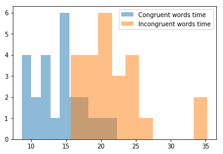

```python
# Build the visualizations here
plt.hist(df.Congruent,alpha=0.5,label='Congruent words time')
plt.hist(df.Incongruent,alpha=0.5,label='Incongruent words time')
plt.legend()
```

**as observed in above descriptive analysis , the range for Congruent words time is narrower and their min and max value is less than that for Incongruent words time**

**the two distributions doesn't have a definite shape , we can observe that some of the Incogruent words times are higher than most of the other Incongruent words time**

**the Incongruent words time distribution is more spreadout**

**the mode of the Incongruent words time is around 21 and that of congruent words is around 14, also the mode is nearly the same values around (20,15)for Incongruent words and congruent words respectively**

(5) Now, perform the statistical test and report your results. What is your confidence level or Type I error associated with your test? What is your conclusion regarding the hypotheses you set up? Did the results match up with your expectations? **Hint:** Think about what is being measured on each individual, and what statistic best captures how an individual reacts in each environment.

**Specifyinig confidence level of 95% and a permitted alpha(Type one error) of 0.05 (5%)**

**building on the assumption that the dataset represent a sample of the population i will get the difference in mean between the congruent and incongruent words time statistic from the sample**

--this will be used latter to examine whether the difference of our sample is significant or not--

**then adding another assumption that the sample is representative of the population i will use bootstraping to build the sampling distribution and then perform the apropriate statistical tests**

**Steps :**

**1-building a sampling distribution of difference between the 2 samples representing tests on each set of words between congruent and incongruent words time**

**2- identifying the confidence interval and the margin of error of the difference between means of the congruent and incongruent words time**

**we shall use 2 methods for simulating the results of a confidence intervals :**

**a-Bootstraping**

**b-Traditional methods for difference between means-->i chose to use t-test confidence interval because the data has the following attributes :**

```
 a-the dependent variable is quantative

 b-the 2 means are dependent , why ? If the measurements are quantitative and taken twice from each subject the analysis will   involve comparing two dependent means.

 c-it is a comparison between 2 groups
```

**3-Carrying a hypothesis test assuming the null hypothesis to have the difference equal zero , the alternative hypothesis is that mean response time of Incogruent condition is higher than that of the Congruent :**

**using two ways :**

**a-Simulating the null hypothesis and getting the p-value**

**b-Using paired t-tests to compare means from the scipy library**

using paired t-tests to compare means has underlying assumptions :

```
a-Samples or sets of data used to produce the difference scores are linked in the population through repeated measurement,   natural association, or matching (paired samples)

b-The differences of the pairs follow a normal distribution or the number of pairs is large (note here that if the number of pairs is < 30, we need to check whether the differences are normal, but we do not need to check for the normality of each population)  -- > **the differences between response time of congruent and incongruent means showed a normal distribution**

c-Random sampling from a defined population
```

**4- Using linear regression to model the relation between time taken to read and the type of word read , i will compute that by altering the dataset where a column named 'time taken' contain the time of all words and another categorical column 'incongruent' is added having values ( 1 for incongruent and 0 for incongruent )**

**using dummy variables i shall fit a linear regression and explore the summary test to examine whether there is significance , taking in consideration that p-value count for two-tailed t-test**

references :https://onlinecourses.science.psu.edu/stat500/node/51/

```python
# tests the null hypothesis that the data was drawn from a normal distribution
from scipy.stats import shapiro
stat, p1 = shapiro(df.Congruent)
stat,p2=shapiro(df.Incongruent)
print(p1,p2)
```

```
0.689803421497345 0.0025900385808199644
```

```python
actual_diff=df.Incongruent.mean()-df.Congruent.mean()
actual_diff
```

```
7.964791666666667
```

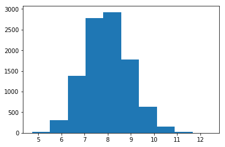

```python
#building a sample distribution for the difference between means using bootstraping , the diffs distribution is nomraly distributed
#so we can use paired t-tests
diffs=[]
for _ in range(10000):
    sample=df.sample(df.shape[0],replace=True)
    c_time=sample.Congruent.mean()
    inc_time=sample.Incongruent.mean()
    diff=inc_time-c_time
    diffs.append(diff)
#diffs=np.array(diffs)
plt.hist(diffs)
```

```python
#confidence interval by bootstraping  ---> here the confidence interval of 95% doesn't include zero which indicates
#our results is significant
np.percentile(diffs, 2.5), np.percentile(diffs, 97.5)
```

```
(6.174706249999998, 9.935060416666662)
```

```python
#confidence interval using traditional methods : t-test --> also the interval doesn't include zero (the null hypothesis assumption)

X1 =  df.Incongruent
X2 =  df.Congruent
cm = sms.CompareMeans(sms.DescrStatsW(X1), sms.DescrStatsW(X2))
print(cm.tconfint_diff(usevar='unequal',alternative='larger'))
```

```
(5.914455829278234, inf)
```

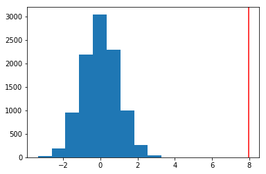

```python
#now performing the hypthesis test by : simulating the null hypothesis and calculating the p-value
#first 1 tailed test

null_mean=0
null_vals = np.random.normal(null_mean, np.std(diffs), 10000) # Here are 10000 draws from the sampling distribution under the null
plt.hist(null_vals)
plt.axvline(actual_diff, color='red')
```

```python
#calculating p value for 1 tailed test , alternative hypothesis : the difference between incongruent and congruent words time
#is more than zero ---> the p-value shows significance as it is below 0.05 , we can reject the null
(null_vals>actual_diff).mean()
```

```
0.0
```

using paired t-tests :

using the function : scipy.stats.ttest_rel(a, b, axis=0) where it :

Calculates the T-test on TWO RELATED samples of scores, a and b.

This is a two-sided test for the null hypothesis that 2 related or repeated samples have identical average (expected) values.

as we are aiming for 1 tailed test so given p and t values from a two-tailed test from that function , **we would reject the null hypothesis of a greater-than test when p/2 < alpha and t > 0**

that is after computing from the cell below : ( 4.103000585711178e-08/2 ) < 0.05 , and 8.020706944109957 >0

**so we can reject the null**

references : https://stackoverflow.com/questions/15984221/how-to-perform-two-sample-one-tailed-t-test-with-numpy-scipy https://docs.scipy.org/doc/scipy-0.16.1/reference/generated/scipy.stats.ttest_rel.html

```python
stats.ttest_rel(df.Incongruent,df.Congruent,axis=0)
```

```
Ttest_relResult(statistic=8.020706944109957, pvalue=4.103000585711178e-08)
```

```python
#altering the data set
df_new=pd.DataFrame()

df_new['time_taken']=pd.concat([df.Congruent,df.Incongruent])
df_new['Incongruent_word']= [0]*24 + [1]*24
df_new['intercept']= 1
df_new.reset_index(inplace=True)

lm=sm.OLS(df_new['time_taken'],df_new[['intercept','Incongruent_word']])
results=lm.fit()
results.summary()
```

OLS Regression Results

| Dep. Variable: | time_taken | R-squared: | 0.481 |
| --- | --- | --- | --- |
| Model: | OLS | Adj. R-squared: | 0.470 |
| Method: | Least Squares | F-statistic: | 42.67 |
| Date: | Thu, 11 Oct 2018 | Prob (F-statistic): | 4.59e-08 |
| Time: | 20:48:44 | Log-Likelihood: | -136.24 |
| No. Observations: | 48 | AIC: | 276.5 |
| Df Residuals: | 46 | BIC: | 280.2 |
| Df Model: | 1 |  |  |
| Covariance Type: | nonrobust |  |  |

|  | coef | std err | t | P>\|t\| | [0.025 | 0.975] |
| --- | --- | --- | --- | --- | --- | --- |
| intercept | 14.0511 | 0.862 | 16.297 | 0.000 | 12.316 | 15.787 |
| Incongruent_word | 7.9648 | 1.219 | 6.532 | 0.000 | 5.510 | 10.419 |

| Omnibus: | 15.004 | Durbin-Watson: | 1.988 |
| --- | --- | --- | --- |
| Prob(Omnibus): | 0.001 | Jarque-Bera (JB): | 17.214 |
| Skew: | 1.178 | Prob(JB): | 0.000183 |
| Kurtosis: | 4.748 | Cond. No. | 2.62 |

Warnings:  
[1] Standard Errors assume that the covariance matrix of the errors is correctly specified.

**from the p-value in the summary results the incongruent words time is significantly different from the congruent word times** **the regression line equation is 7.9648 x + 14.0511 , it indicates that there is a difference of 7.96 between time taken to read Incongruent words and the congruent words** **From the r-squared value , the change in the incongruent words counts for 48.1% of the change that occurs in the time taken to read a word**

(6) Optional: What do you think is responsible for the effects observed? Can you think of an alternative or similar task that would result in a similar effect? Some research about the problem will be helpful for thinking about these two questions!

**there are many different theories to explain the stroop effect two of the main theories :**

*1-Processing speed* *This theory suggests there is a lag in the brain's ability to recognize the color of the word since the brain reads words faster than it recognizes colors. This is based on the idea that word processing is significantly faster than color processing. In a condition where there is a conflict regarding words and colors (e.g., Stroop test). if the task is to report the color, the word information arrives at the decision-making stage before the color information which presents processing confusion. Conversely, if the task is to report the word, because color information lags after word information, a decision can be made ahead of the conflicting information.*

*2-Selective attention* *The Selective Attention Theory suggests that color recognition, as opposed to reading a word, requires more attention. The brain needs to use more attention to recognize a color than to encode a word, so it takes a little longer.The responses lend much to the interference noted in the Stroop task. This may be a result of either an allocation of attention to the responses or to a greater inhibition of distractors that are not appropriate responses.*

variations on the test :

*Warped words:* *For example, the warped words Stroop effect produces the same findings similar to the original Stroop effect. Much like the Stroop task, the printed word's color is different from the ink color of the word; however, the words are printed in such a way that it is more difficult to read (typically curved-shaped).The idea here is the way the words are printed slows down both the brain's reaction and processing time, making it harder to complete the task.*

*Emotional* *The emotional Stroop effect serves as an information processing approach to emotions. In an emotional Stroop task, an individual is given negative emotional words like "grief," "violence," and "pain" mixed in with more neutral words like "clock," "door," and "shoe".Just like in the original Stroop task, the words are colored and the individual is supposed to name the color. Research has revealed that individuals that are depressed are more likely to say the color of a negative word slower than the color of a neutral word.While both the emotional Stroop and the classic Stroop involve the need to suppress irrelevant or distracting information, there are differences between the two. The emotional Stroop effect emphasizes the conflict between the emotional relevance to the individual and the word; whereas, the classic Stroop effect examines the conflict between the incongruent color and word.*